This notebook shows my last submission to the [OEMC hackathon: European Land Cover Classification](https://www.kaggle.com/competitions/oemc-hackathon-eu-land-cover-classification/overview) hosted in September 2023 by the [Open-Earth-Monitor (OEMC) project](https://earthmonitor.org/).

Note that for running this notebook you will need GPU runtime, as I used XGBoost ad Bayesian optimization running on GPU.

# 0) Install and import needed libraries

```python
!pip install hyperopt -q
```

```python
!pip install xgboost -q
```

```python
import requests
import random
import pandas as pd
import numpy as np
import seaborn as sns
import matplotlib.pyplot as plt
import xgboost as xgb
from sklearn.model_selection import train_test_split
from sklearn.metrics import f1_score
from hyperopt import fmin, tpe, hp, STATUS_OK, Trials
```

# 1) Import and prepare dataset

Get the data from Zenodo

```python
train_url = 'https://zenodo.org/record/8306554/files/train.csv.gz?download=1'
test_url = 'https://zenodo.org/record/8306554/files/test.csv.gz?download=1'

r_train = requests.get(train_url, allow_redirects=True)
f_train = 'land_cover_train.csv.gz'

r_test = requests.get(test_url, allow_redirects=True)
f_test = 'land_cover_test.csv.gz'

print(f"Downloading {f_train}")
open(f_train, 'wb').write(r_train.content)

print(f"Downloading {f_test}")
open(f_test, 'wb').write(r_test.content)
```

```
Downloading land_cover_train.csv.gz
Downloading land_cover_test.csv.gz
```

```
36033342
```

Load train and test sets

```python
df_train = pd.read_csv(f_train, index_col='sample_id')
df_test = pd.read_csv(f_test, index_col='sample_id')
```

Check how many classes there are in the dataset

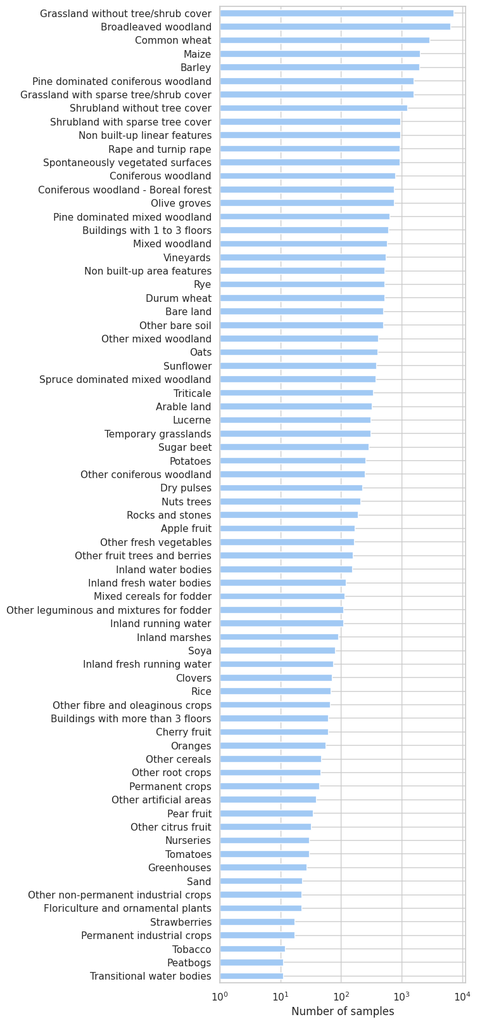

```python
sns.set_theme(style="whitegrid", palette="pastel")
sns.set_context("notebook")

ax = pd.DataFrame(df_train['land_cover_label'].value_counts()).sort_values('land_cover_label').plot(kind='barh', figsize=(5, 20), log=True, legend=False)
ax.set_xlabel("Number of samples")
```

Check how many features (explanatory variables) there are

```python
feat_cols = df_train.columns[3:]
print(f'Number of features: {len(feat_cols)}')
```

```
Number of features: 416
```

Split features and class labels

```python
X = df_train[feat_cols].to_numpy()
y = df_train['land_cover'].to_numpy()
```

Time to set seeds to ensure results reproducibility!

```python
random.seed(123)
np.random.seed(123)
```

As for this hackathon there are no labels available for the test set, it is a good choice to split the dataset in training and validation sets.

```python
# stratify argument will take care of potential class imbalances
X_train, X_val, y_train, y_val = train_test_split(X, y, test_size=0.3,
                                                  random_state=1996,
                                                  stratify=y)
```

# 2) Model development

After a number of attempts, I got the best result by using XGBoost and Bayesian optimization using the library [**hyperopt**](http://hyperopt.github.io/hyperopt/). I tried a few feature engineering methods (PCA, feature selection based on correlation thresholds, Recurrent Feature Elimination, SMOTE to oversample the underrepresented classes or undersample the overrepresented ones) but in the end I got a better F1 score by avoiding those and just using the full dataset.

```python
# Create a hyperparameters space for the Bayesian optimization algorithm
space = {
    'max_depth': hp.choice('max_depth', range(5, 30, 1)),
    'learning_rate': hp.quniform('learning_rate', 0.01, 0.5, 0.01),
    'n_estimators': hp.choice('n_estimators', range(20, 205, 5)),
    'gamma': hp.quniform('gamma', 0, 0.50, 0.01),
    'min_child_weight': hp.quniform('min_child_weight', 1, 10, 1),
    'subsample': hp.uniform('subsample', 0.1, 1),
    'colsample_bytree': hp.uniform('colsample_bytree', 0.1, 1)
}
```

```python
def objective(space):
    """
    Objective function for hyperparameter optimization of XGBoost classifier.
    This function trains an XGBoost classifier on the training data with a given set of hyperparameters
    and evaluates its performance on a validation set using the F1 score. The function is designed to be
    used with Bayesian optimization technique provided by the `hyperopt` library.

    Parameters:
    - space (dict): A dictionary containing values for hyperparameters to be optimized.
        Expected keys are:
        - 'n_estimators': Number of boosting rounds.
        - 'max_depth': Maximum depth of a tree.
        - 'learning_rate': Boosting learning rate.
        - 'gamma': Minimum loss reduction required to make a further partition.
        - 'min_child_weight': Minimum sum of instance weight (hessian) needed in a child.
        - 'subsample': Subsample ratio of the training instances.
        - 'colsample_bytree': Subsample ratio of columns when constructing each tree.
        - 'tree_method': The tree construction algorithm used in XGBoost. Set to 'gpu_hist' for GPU support.

    Returns:
    - dict: A dictionary with two keys:
        - 'loss': The negative F1 score (as we want to maximize F1, but
                    optimization routines typically minimize).
        - 'status': Status of the trial. Typically set to STATUS_OK
                     if the trial is successful.
    """
    clf = xgb.XGBClassifier(
        n_estimators = space['n_estimators'],
        max_depth = int(space['max_depth']),
        learning_rate = space['learning_rate'],
        gamma = space['gamma'],
        min_child_weight = space['min_child_weight'],
        subsample = space['subsample'],
        colsample_bytree = space['colsample_bytree'],
        tree_method='gpu_hist'
    )

    clf.fit(X_train, y_train)

    pred = clf.predict(X_val)
    f1 = f1_score(y_val, pred, average='weighted')
    return {'loss': -f1, 'status': STATUS_OK}
```

```python
trials = Trials()
best = fmin(fn=objective,
            space=space,
            algo=tpe.suggest,
            max_evals=50,
            trials=trials)
```

```python
# show the best combination of parameters found by the Bayesian optimization
print(best)
```

```
{'colsample_bytree': 0.6244271153780622, 'gamma': 0.35000000000000003, 'learning_rate': 0.08, 'max_depth': 11, 'min_child_weight': 9.0, 'n_estimators': 34, 'subsample': 0.4362265568064397}
```

```python
final_model = xgb.XGBClassifier(**best)
final_model.fit(X_train, y_train) # refit the model with the best parameters
```

```
XGBClassifier(base_score=None, booster=None, callbacks=None,
              colsample_bylevel=None, colsample_bynode=None,
              colsample_bytree=0.6244271153780622, early_stopping_rounds=None,
              enable_categorical=False, eval_metric=None, feature_types=None,
              gamma=0.35000000000000003, gpu_id=None, grow_policy=None,
              importance_type=None, interaction_constraints=None,
              learning_rate=0.08, max_bin=None, max_cat_threshold=None,
              max_cat_to_onehot=None, max_delta_step=None, max_depth=11,
              max_leaves=None, min_child_weight=9.0, missing=nan,
              monotone_constraints=None, n_estimators=34, n_jobs=None,
              num_parallel_tree=None, objective='multi:softprob',
              predictor=None, ...)
```

If desired, it is possible to save the best model and re-upload it later (if, for instance, the optimization algorithm takes hours to run)

```python
from joblib import dump, load
from google.colab import files

model_save_path = "final_model.joblib"
dump(final_model, model_save_path)

# download the best model on your local machine
files.download(model_save_path)

# reupload the file with the best parameters
uploaded = files.upload()

# load the best parameters from the file
loaded_best_params = load('best_params.joblib')

final_model = xgb.XGBClassifier(**loaded_best_params)
```

Let's evaluate the best model

```python
y_val_pred = final_model.predict(X_val)

# Evaluate the model
f1_val = f1_score(y_val, y_val_pred, average='weighted')
print(f"Validation F1 score with XGBoost after Bayesian optimization: {f1_val:.4f}")
```

```
Validation F1 score with XGBoost after Bayesian optimization: 0.4240
```

# Submission

Here I fit again the model, this time on the whole training dataset;

```python
final_model.fit(X, y)
```

```python
X_test = df_test[feat_cols].to_numpy()
y_test_pred = final_model.predict(X_test)
```

Finally, I prepare the csv for the submission and download it on my local machine.

```python
df_subm = pd.DataFrame({'land_cover': y_test_pred}, index=pd.Index(df_test.index, name='sample_id'))
f_subm = 'xgboost_hyperopt_fulldata.csv'

df_subm.to_csv(f_subm)
print(f"Submission file {f_subm} ready (shape={df_subm.shape})")
```

```python
from google.colab import files
files.download(f_subm)
```